## Chi-Square Test of Independence: Playlist Type vs. Track Genre

In this project, we first performed a Chi-Square Test of Independence on all the playlists to examine the relationship between playlist type (e.g., workout, chill, motivation) and track genre. The goal was to determine if certain playlist types are more likely to contain specific genres, for example, if workout playlist contains a lot of hip-hop or chill playlist contains a lot of lofi songs, thus providing valuable insights for improving playlist recommendation systems.

## Hypotheses:

**Null Hypothesis (H0):** Playlist type and track genre are independent. In other words, the typer of playlist has no effect on the genres of tracks it contains.

**Alternative Hypothesis (H1):* Playlist type and track genre are dependent. This means that the type of playlist is associated with the genres of tracks it contains.

## Test Procedure:

1. Contingency Table: A table was created with playlist types as rows and track genres as columns, showing the frequency of each genre within each playlist type.
2. Chi-Square Calculation: We calculated the Chi-Square statistic to compare observed frequencies with expected frequencies under the assumption of independence.
3. Hypothesis Testing: A p-value was obtained to test the null hypothesis. If the p-value was less than 0.05, we rejected the null hypothesis and concluded that playlist type and track genre are dependent.

## Results:

**Test Statistic (X-squared):** 9616.6

**Degrees of Freedom (df):** 240

**p-value:** < 2.2e-16

The p-value of less than 2.2e-16 is extremely small, indicating strong evidence against the null hypothesis. As a result, we reject the null hypothesis and conclude that playlist type and track genre are statistically significantly associated. This means that certain types of playlists (e.g., workout, chill) are more likely to feature specific genres, suggesting a dependency between playlist type and genre.

## Conclusion:

The results of the Chi-Square Test of Independence provide compelling evidence that playlist types influence the genres of tracks they contain. This insight can be used to improve playlist recommendation systems by incorporating genre preferences based on the type of playlist a user is interested in.

```r
library(dplyr)
```

```r
library(ggplot2)
library(RColorBrewer)

# Specify the folder containing the CSV files
folder_path <- "/Users/ft_kiranraj/Desktop/Statsproject/MMerged_csv/"

# Step 1: Read and aggregate all CSV files
# List all CSV files in the folder
csv_files <- list.files(path = folder_path, pattern = "*.csv", full.names = TRUE)

# Initialize an empty data frame to store aggregated data
all_data <- data.frame(final_genre = character(), Theme = character(), stringsAsFactors = FALSE)

# Loop through each CSV file, read it, and append the data
for (file in csv_files) {
  # Read the CSV file
  data <- read.csv(file)

  # Extract the playlist theme (Type)
  playlist_theme <- unique(data$Type)  # All rows in a file share the same Type

  # Check for consistency: ensure only one theme exists per file
  if (length(playlist_theme) != 1) {
    stop(paste("Error: File", file, "contains multiple or no unique themes in the 'Type' column."))
  }

  # Add the theme as a new column
  data <- data %>%
    select(final_genre) %>%            # Keep only the genre column
    mutate(Theme = playlist_theme)    # Add the playlist theme as a new column

  # Append to the combined data frame
  all_data <- rbind(all_data, data)
}

# View the combined dataset
print("Aggregated Data:")
```

```
## [1] "Aggregated Data:"
```

```r
print(head(all_data))
```

```
##   final_genre   Theme
## 1         pop workout
## 2         pop workout
## 3         pop workout
## 4         pop workout
## 5         pop workout
## 6 hip_hop_rap workout
```

```r
# Step 2: Create a contingency table
contingency_table <- table(all_data$final_genre, all_data$Theme)

# Save the contingency table to a CSV file
write.csv(as.data.frame(contingency_table), "/Users/ft_kiranraj/Desktop/Statsproject/contingency_table.csv")

# Step 3: Perform the Chi-Square Test of Independence
chi_square_test <- chisq.test(contingency_table)
# Print the hypothesis
cat("Null Hypothesis (H0): There is no association between song genres and playlist themes.\n")
```

```
## Null Hypothesis (H0): There is no association between song genres and playlist themes.
```

```r
cat("Alternative Hypothesis (H1): There is an association between song genres and playlist themes.\n\n")
```

```
## Alternative Hypothesis (H1): There is an association between song genres and playlist themes.
```

```r
# Print the chi-square test results
print("Chi-Square Test Results:")
```

```
## [1] "Chi-Square Test Results:"
```

```r
print(chi_square_test)
```

```
##
##  Pearson's Chi-squared test
##
## data:  contingency_table
## X-squared = 9616.6, df = 240, p-value < 2.2e-16
```

```r
# Interpret the p-value and print hypothesis result
alpha <- 0.05  # Significance level (usually 0.05)
p_value <- chi_square_test$p.value

if (p_value < alpha) {
  cat("Since the p-value (", p_value, ") is less than the significance level (", alpha, "), we reject the null hypothesis.\n", sep = "")
  cat("Conclusion: There is a statistically significant association between song genres and playlist themes.\n")
} else {
  cat("Since the p-value (", p_value, ") is greater than the significance level (", alpha, "), we fail to reject the null hypothesis.\n", sep = "")
  cat("Conclusion: There is no statistically significant association between song genres and playlist themes.\n")
}
```

```
## Since the p-value (0) is less than the significance level (0.05), we reject the null hypothesis.
## Conclusion: There is a statistically significant association between song genres and playlist themes.
```

```r
# Save Chi-Square results summary to a text file
sink("/Users/ft_kiranraj/Desktop/Statsproject/chi_square_test_results.txt")
cat("Null Hypothesis (H0): There is no association between song genres and playlist themes.\n")
```

```
## Null Hypothesis (H0): There is no association between song genres and playlist themes.
```

```r
cat("Alternative Hypothesis (H1): There is an association between song genres and playlist themes.\n\n")
```

```
## Alternative Hypothesis (H1): There is an association between song genres and playlist themes.
```

```r
print(chi_square_test)
```

```
##
##  Pearson's Chi-squared test
##
## data:  contingency_table
## X-squared = 9616.6, df = 240, p-value < 2.2e-16
```

```r
if (p_value < alpha) {
  cat("Since the p-value (", p_value, ") is less than the significance level (", alpha, "), we reject the null hypothesis.\n", sep = "")
  cat("Conclusion: There is a statistically significant association between song genres and playlist themes.\n")
} else {
  cat("Since the p-value (", p_value, ") is greater than the significance level (", alpha, "), we fail to reject the null hypothesis.\n", sep = "")
  cat("Conclusion: There is no statistically significant association between song genres and playlist themes.\n")
}
```

```
## Since the p-value (0) is less than the significance level (0.05), we reject the null hypothesis.
## Conclusion: There is a statistically significant association between song genres and playlist themes.
```

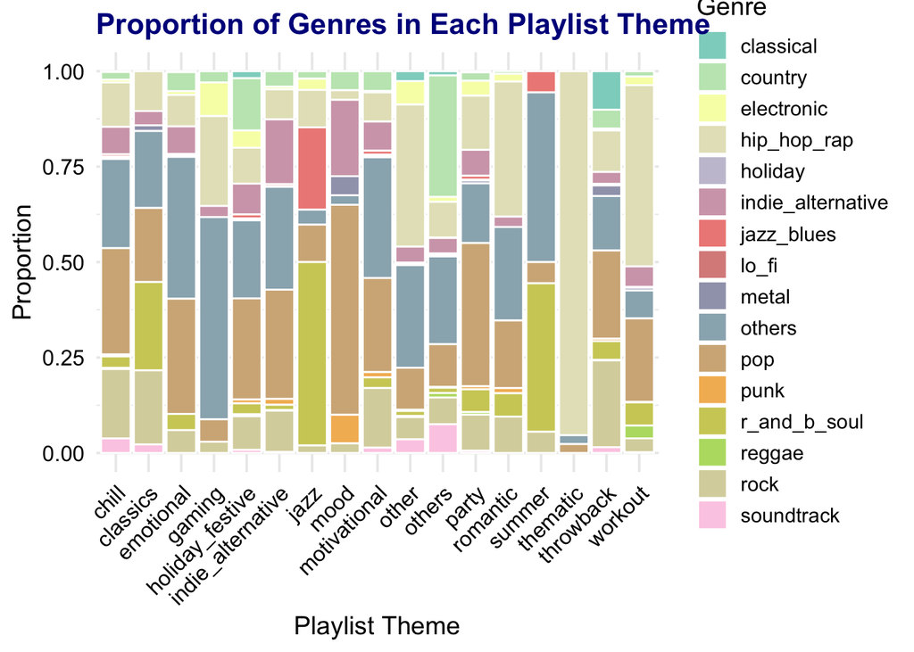

```r
sink()

# Step 4: Generate Visualizations

# Custom color palette based on the number of genre categories
num_genres <- length(unique(all_data$final_genre))
genre_palette <- colorRampPalette(RColorBrewer::brewer.pal(8, "Set3"))(num_genres)

all_data$final_genre <- factor(all_data$final_genre)

# Custom color palette based on the number of playlist themes
num_themes <- length(unique(all_data$Theme))
theme_palette <- colorRampPalette(RColorBrewer::brewer.pal(8, "Set2"))(num_themes)

# 1. Bar Plot: Distribution of Genres Across Playlist Themes
bar_plot <- ggplot(all_data, aes(x = Theme, fill = final_genre)) +
  geom_bar(position = "dodge", color = "black") +  # Dodge for side-by-side bars
  scale_fill_manual(values = genre_palette) +  # Use the custom genre palette
  labs(
    title = "Distribution of Song Genres Across Playlist Themes",
    x = "Playlist Theme",
    y = "Number of Tracks"
  ) +
  theme_minimal(base_size = 14) +  # Improve plot readability with a larger base font size
  theme(
    legend.position = "right",  # Move the legend to the right
    axis.text.x = element_text(angle = 45, hjust = 1),  # Rotate x-axis labels for better readability
    axis.text = element_text(size = 12),  # Make the axis text larger for clarity
    axis.title = element_text(size = 14),  # Make axis titles larger
    plot.title = element_text(size = 16, face = "bold")  # Make the plot title larger and bold
  )

# 2. Heatmap: Contingency Table Visualization
heatmap_data <- as.data.frame(contingency_table)
colnames(heatmap_data) <- c("Genre", "Theme", "Count")

# Create the heatmap with a vibrant custom color palette
heatmap_plot <- ggplot(heatmap_data, aes(x = Theme, y = Genre, fill = Count)) +
  geom_tile(color = "white") +  # White borders between tiles for better distinction
  scale_fill_gradientn(colors = c("yellow", "orange", "red", "darkred")) +  # Custom vibrant color gradient
  labs(
    title = "Heatmap of Genre-Theme Associations",
    x = "Playlist Theme",
    y = "Genre",
    fill = "Count"
  ) +
  theme_minimal(base_size = 14) +  # Minimal theme for cleaner visuals
  theme(
    axis.text.x = element_text(angle = 45, hjust = 1),  # Rotate x-axis labels for better readability
    legend.position = "right",  # Place legend to the right
    plot.title = element_text(size = 16, face = "bold"),  # Bold title for emphasis
    axis.text = element_text(size = 12),  # Larger axis text for clarity
    axis.title = element_text(size = 14)  # Larger axis titles
  )

agg_data <- all_data %>%
  group_by(Theme, final_genre) %>%
  summarise(Count = n(), .groups = 'drop')  # Count the occurrences of each genre per theme

# Step 2: Normalize the counts to get proportions
agg_data <- agg_data %>%
  group_by(Theme) %>%
  mutate(Proportion = Count / sum(Count))  # Calculate proportions within each theme

# Step 3: Create the mosaic plot (bar plot with proportions)
mosaic_plot <- ggplot(agg_data, aes(x = Theme, y = Proportion, fill = final_genre)) +
  geom_bar(stat = "identity", position = "stack", color = "white") +  # Use 'identity' to plot proportions
  scale_fill_manual(values = genre_palette) +  # Custom color palette for genres
  labs(
    title = "Proportion of Genres in Each Playlist Theme",
    x = "Playlist Theme",
    y = "Proportion",
    fill = "Genre"
  ) +
  theme_minimal(base_size = 14) +
  theme(
    axis.text.x = element_text(angle = 45, hjust = 1),
    legend.position = "right",
    plot.title = element_text(size = 16, face = "bold", color = "darkblue"),
    axis.text = element_text(size = 12, color = "black"),
    axis.title = element_text(size = 14, color = "black")
  )



mosaic_plot
```

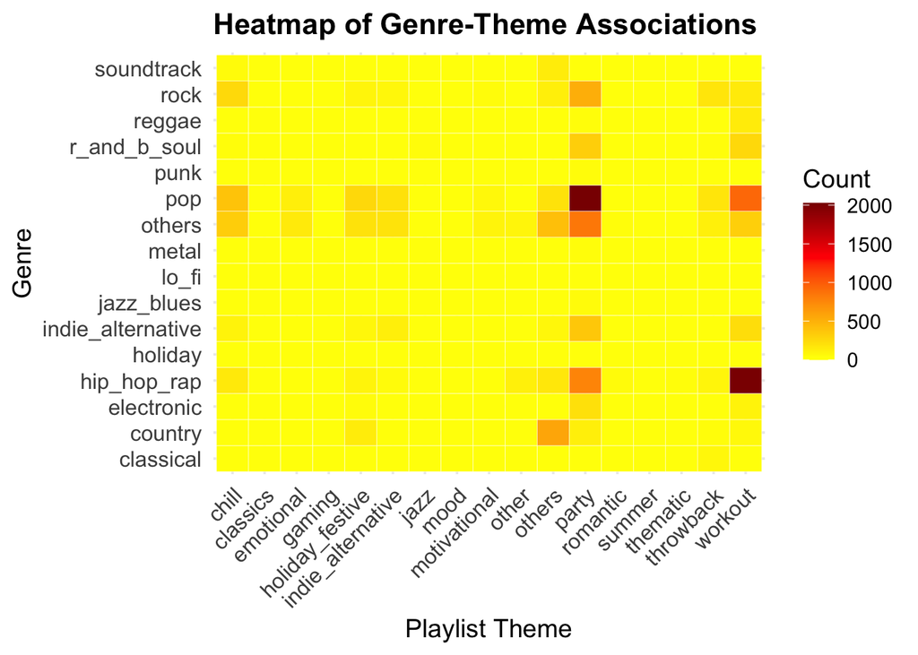

```r
heatmap_plot
```

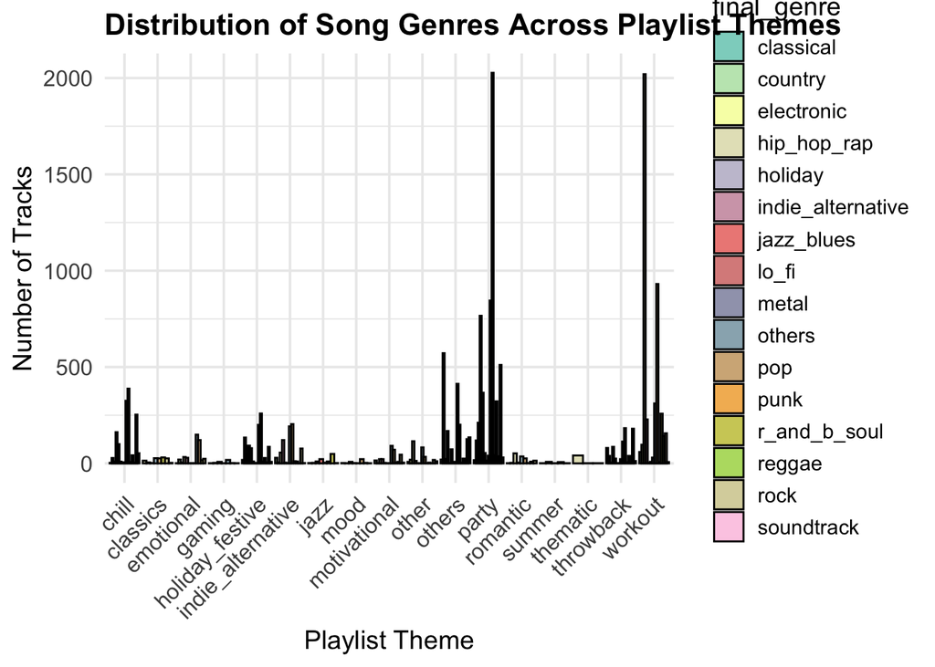

```r
bar_plot
```

## Chi-Square Test of Independence: Comparing User Playlist Genre Distribution vs. Recommendation Candidate

Building on the insight that certain playlist types are more likely to contain specific genres, we further applied this understanding to assess whether a given recommendation candidate aligns with a user’s playlist genre preferences. The approach involved comparing the track genre distribution of a user’s playlists to that of a recommendation candidate using the Chi-Square Test of Independence.

## Hypotheses:

**Null Hypothesis (H0):** There is no significant difference between the genre distribution of the user’s playlists and the recommendation candidate. This means the recommendation candidate is similar to the user’s playlists in terms of genre distribution.

**Alternative Hypothesis (H1):** There is a significant difference between the genre distribution of the user’s playlists and the recommendation candidate. This suggests the recommendation candidate does not align well with the user’s playlist genre preferences.

## Test Procedure:

1. **Genre Distribution Comparison:** We calculated the genre distribution of the user’s playlists and the recommendation candidate. A contingency table was created to represent the frequency of each genre within both the user’s playlists and the recommendation candidate.
2. **Chi-Square Calculation:** The Chi-Square statistic was calculated to compare the genre distributions. If the observed and expected distributions were significantly different, this would indicate a mismatch between the user’s preferences and the recommendation candidate.
3. **Hypothesis Testing:** A p-value was obtained to test the null hypothesis. If the p-value was less than 0.05, we rejected the null hypothesis, meaning the recommendation candidate did not align with the user’s playlist genre preferences, and thus would not be recommended.

```r
# Function to read playlists and prepare data for testing
prepare_playlist_data <- function(csv_files, playlist_type) {
  all_data <- data.frame(final_genre = character(), Theme = character(), stringsAsFactors = FALSE)

  # Loop through each CSV file (user playlists or recommended playlist)
  for (file in csv_files) {
    data <- read.csv(file)
    playlist_theme <- unique(data$Type)  # All rows in a file share the same Type

    # Ensure only one theme exists per file
    if (length(playlist_theme) != 1) {
      stop(paste("Error: File", file, "contains multiple or no unique themes in the 'Type' column."))
    }

    # Add the theme as a new column
    data <- data %>%
      select(final_genre) %>%            # Keep only the genre column
      mutate(Theme = playlist_theme)     # Add the playlist theme as a new column

    # Append to the combined data frame
    all_data <- rbind(all_data, data)
  }

  # Add playlist type information (User/Recommended)
  all_data$Playlist_Type <- playlist_type
  return(all_data)
}
# 1. Read and aggregate the data for user playlists (20 files)
user_playlist_files <- list.files(path = "/Users/ft_kiranraj/Desktop/user_playlist/", pattern = "*.csv", full.names = TRUE)
user_data <- prepare_playlist_data(user_playlist_files, "User")

# 2. Read and aggregate the recommended playlist data (1 file)
recommended_playlist_file <- "/Users/ft_kiranraj/Desktop/recommendation_candidates/playlist_261.csv"
recommended_data <- prepare_playlist_data(list(recommended_playlist_file), "Recommended")

# 3. Combine user data and recommended data for comparison
combined_data <- rbind(user_data, recommended_data)

# 4. Create a contingency table for the Chi-Square test
contingency_table <- table(combined_data$final_genre, combined_data$Playlist_Type)

# Perform the Chi-Square Test of Independence
chi_square_test <- chisq.test(contingency_table)
# Print the hypothesis
cat("Null Hypothesis (H0): There is no significant difference in genre distribution between user playlists and the recommended playlist.\n")
```

```
## Null Hypothesis (H0): There is no significant difference in genre distribution between user playlists and the recommended playlist.
```

```r
cat("Alternative Hypothesis (H1): There is a significant difference in genre distribution between user playlists and the recommended playlist.\n\n")
```

```
## Alternative Hypothesis (H1): There is a significant difference in genre distribution between user playlists and the recommended playlist.
```

```r
# Print the Chi-Square test results
print("Chi-Square Test Results:")
```

```
## [1] "Chi-Square Test Results:"
```

```r
print(chi_square_test)
```

```
##
##  Pearson's Chi-squared test
##
## data:  contingency_table
## X-squared = 6.2917, df = 12, p-value = 0.9007
```

```r
# Interpret the p-value and print hypothesis result
alpha <- 0.05  # Significance level (usually 0.05)
p_value <- chi_square_test$p.value

if (p_value < alpha) {
  cat("Since the p-value (", p_value, ") is less than the significance level (", alpha, "), we reject the null hypothesis.\n", sep = "")
  cat("Conclusion: There is a significant difference in genre distribution between user playlists and the recommended playlist.\n")
  cat("Recommendation: Do not recommend the playlist.\n")
} else {
  cat("Since the p-value (", p_value, ") is greater than the significance level (", alpha, "), we fail to reject the null hypothesis.\n", sep = "")
  cat("Conclusion: There is no significant difference in genre distribution between user playlists and the recommended playlist.\n")
  cat("Recommendation: Recommend the playlist.\n")
}
```

```
## Since the p-value (0.9006689) is greater than the significance level (0.05), we fail to reject the null hypothesis.
## Conclusion: There is no significant difference in genre distribution between user playlists and the recommended playlist.
## Recommendation: Recommend the playlist.
```

```r
# Optionally save the Chi-Square results summary to a text file
sink("/Users/ft_kiranraj/Desktop/statsproject/chi_square_test_recommendation_results.txt")
cat("Null Hypothesis (H0): There is no significant difference in genre distribution between user playlists and the recommended playlist.\n")
```

```
## Null Hypothesis (H0): There is no significant difference in genre distribution between user playlists and the recommended playlist.
```

```r
cat("Alternative Hypothesis (H1): There is a significant difference in genre distribution between user playlists and the recommended playlist.\n\n")
```

```
## Alternative Hypothesis (H1): There is a significant difference in genre distribution between user playlists and the recommended playlist.
```

```r
print(chi_square_test)
```

```
##
##  Pearson's Chi-squared test
##
## data:  contingency_table
## X-squared = 6.2917, df = 12, p-value = 0.9007
```

```r
if (p_value < alpha) {
  cat("Since the p-value (", p_value, ") is less than the significance level (", alpha, "), we reject the null hypothesis.\n", sep = "")
  cat("Conclusion: There is a significant difference in genre distribution between user playlists and the recommended playlist.\n")
  cat("Recommendation: Do not recommend the playlist.\n")
} else {
  cat("Since the p-value (", p_value, ") is greater than the significance level (", alpha, "), we fail to reject the null hypothesis.\n", sep = "")
  cat("Conclusion: There is no significant difference in genre distribution between user playlists and the recommended playlist.\n")
  cat("Recommendation: Recommend the playlist.\n")
}
```

```
## Since the p-value (0.9006689) is greater than the significance level (0.05), we fail to reject the null hypothesis.
## Conclusion: There is no significant difference in genre distribution between user playlists and the recommended playlist.
## Recommendation: Recommend the playlist.
```

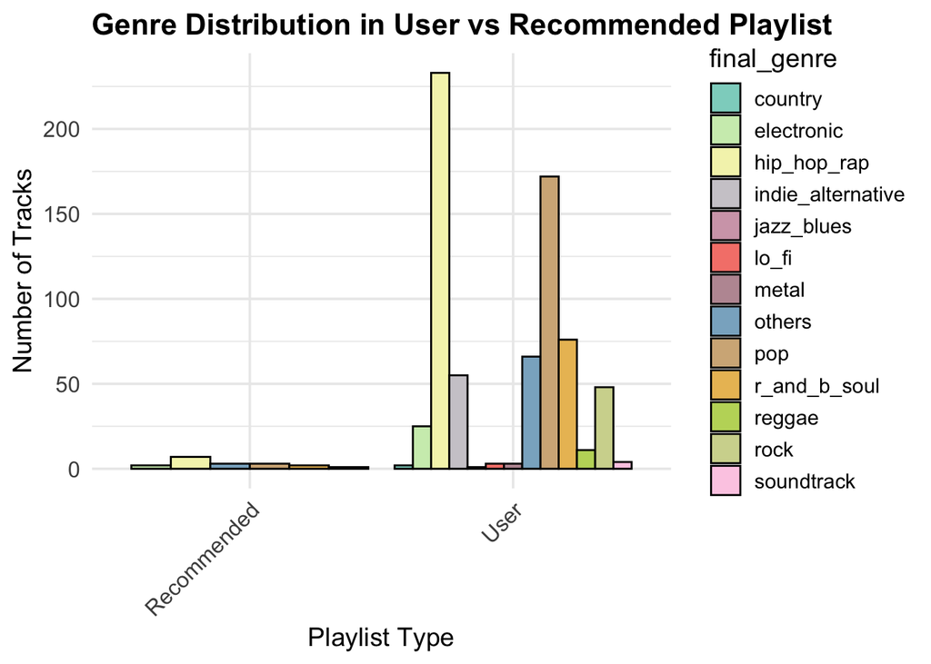

[figure not shown]

```r
sink()

# Visualize the Genre Distribution for User Playlists and Recommended Playlist
# Plot genre distribution for user playlists and the recommended playlist
genre_palette <- colorRampPalette(RColorBrewer::brewer.pal(8, "Set3"))(length(unique(combined_data$final_genre)))

# Bar plot for genre distribution across all playlists (user + recommended)
bar_plot <- ggplot(combined_data, aes(x = Playlist_Type, fill = final_genre)) +
  geom_bar(position = "dodge", color = "black") +  # Side-by-side bars for genres
  scale_fill_manual(values = genre_palette) +  # Custom color palette
  labs(
    title = "Genre Distribution in User vs Recommended Playlist",
    x = "Playlist Type",
    y = "Number of Tracks"
  ) +
  theme_minimal(base_size = 14) +  # Improve readability with larger font size
  theme(
    legend.position = "right",  # Move legend to the right
    axis.text.x = element_text(angle = 45, hjust = 1),  # Rotate x-axis labels
    axis.text = element_text(size = 12),  # Increase font size for axis text
    axis.title = element_text(size = 14),  # Increase font size for axis titles
    plot.title = element_text(size = 16, face = "bold")  # Bold title for emphasis
  )

bar_plot
```

## Results:

Based on the Chi-Square Test results, if the p-value was greater than 0.05, we would fail to reject the null hypothesis and recommend the playlist (H0), indicating that the genre distribution of the recommendation candidate is in alignment with the user’s preferences. On the other hand, if the p-value was less than 0.05, we would reject the null hypothesis (H1) and not recommend the playlist, as it would indicate a mismatch in genre distribution.

## Conclusion:

By comparing the genre distribution of the user’s playlists with that of the recommendation candidate using the Chi-Square Test, we could assess whether the candidate aligns with the user’s musical preferences. This statistical approach helps refine the recommendation process by ensuring that the suggested playlists match the genre preferences of the user, leading to more personalized and relevant recommendations.

**Conclusion of Project:**

We performed descriptive and inferential statistics to analyze whether certain features like track energy, tempo, track genre affect the creation of the playlist. We also performed non-parametric tests to see if a playlist can be recommended based on user’s favorite playlists.